# Mother Care Insights

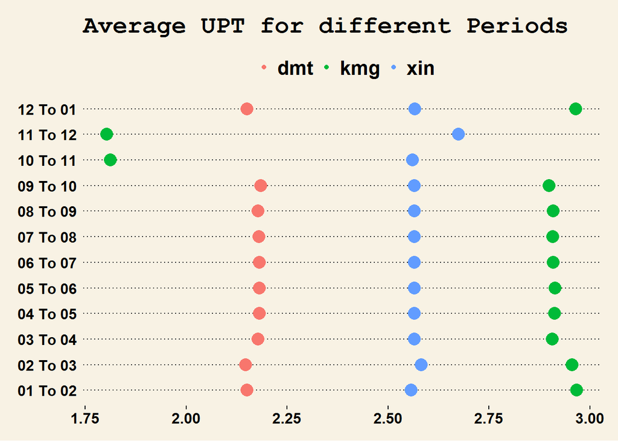

```r
 p <-  ggplot(upt_time, aes(Time_Interval, avg)) +
   geom_point(aes(colour = store, size = 2))+
   theme_wsj() + ggtitle("Average UPT for different Periods")
 p + scale_size(guide = "none") + theme(legend.title = element_blank(),
                                        legend.text = element_text(colour = "black",
                                                                   size = 16, face = "bold"))+
   theme(plot.title = element_text(lineheight = .8, size = 20,face = "bold")) +
   coord_flip()
```

The above plot shows average UPT for a particular day.The plot shows that UPT is highest for KMG stores and lowest for DMT stores on a particular day.

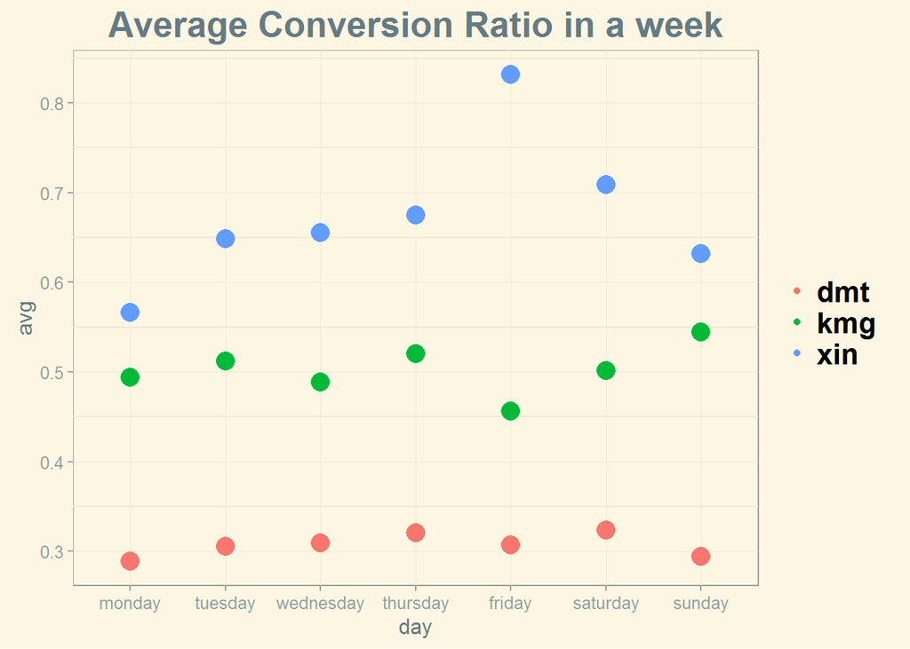

```r
 ###con_store and con time
 p <-  ggplot(con_store, aes(day, avg)) +
   geom_point(aes(colour = store, size = 2))+
   theme_solarized() + ggtitle("Average Conversion Ratio in a week")
 p + scale_size(guide = "none") + theme(legend.title = element_blank(),
                                        legend.text = element_text(colour = "black",
                                                                   size = 16, face = "bold"))+
   theme(plot.title = element_text(lineheight = .8, size = 20,face = "bold"))
```

The above plot shows the average conversion of three stores in a particular week. The conversion ratio is lowest for dmt store and highest for the xin stores

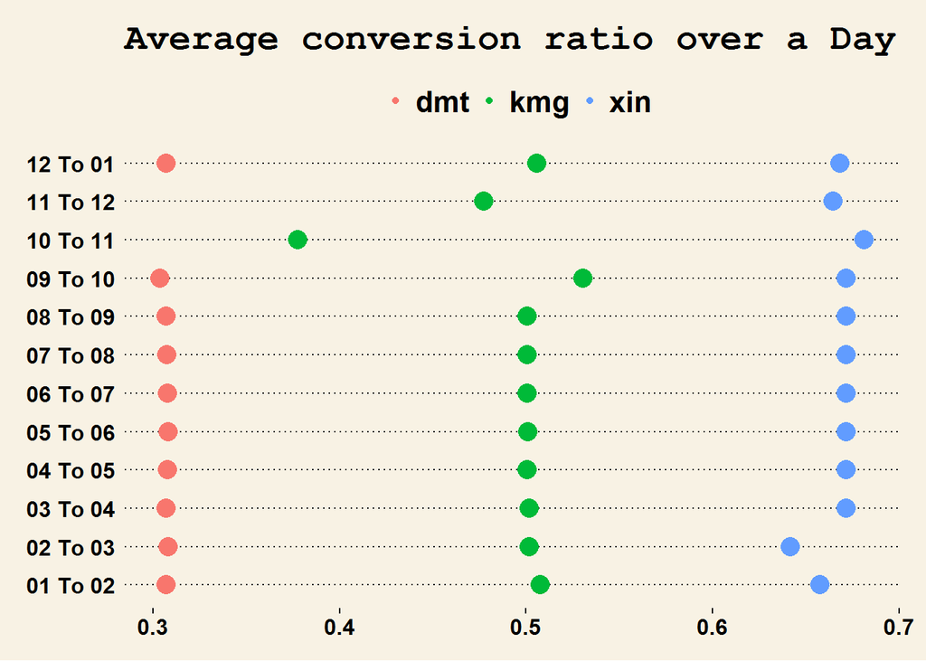

```r
 p <-  ggplot(con_time, aes(Time_Interval, avg)) +
   geom_point(aes(colour = store, size = 2))+
   theme_wsj() + ggtitle("Average conversion ratio over a Day")
 p + scale_size(guide = "none") + theme(legend.title = element_blank(),
                                        legend.text = element_text(colour = "black",
                                                                   size = 16, face = "bold"))+
   theme(plot.title = element_text(lineheight = .8, size = 20,face = "bold")) +
   coord_flip()
```

The plot avove shows the average conversion ratio over a particular day. The conversion ratio is highest for the xin and lowest for the dmt indicating customer cant buy thing they came for.

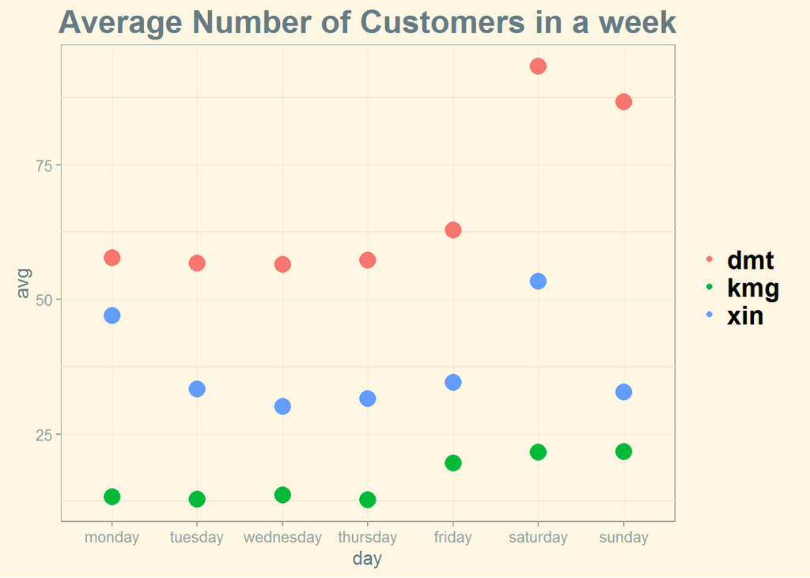

```r
 ###cus_store and cus time
 p <-  ggplot(cus_store, aes(day, avg)) +
   geom_point(aes(colour = store, size = 2))+
   theme_solarized() + ggtitle("Average Number of Customers in a week")
 p + scale_size(guide = "none") + theme(legend.title = element_blank(),
                                        legend.text = element_text(colour = "black",
                                                                   size = 16, face = "bold"))+
   theme(plot.title = element_text(lineheight = .8, size = 20,face = "bold"))
```

The above plot shows the average number of customers in a week for three stores. It is evident that dmt has the highest number of customers peaking over the weekend while kmg has the lowest number of customers on average in a particular week.